# NCAA Modeling 2016

# Commissioner’s Report

## Scores were a bit lower this year

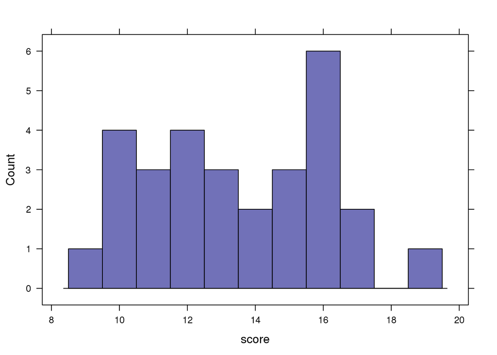

This is in part due to the early loss by Michigan State. We don’t have official records going back to check, but this was likely the single biggest waste of capital in the history of this event. 25 contestants chose MSU for a combined capital expenditure of 450 points with a return on investment of 0.

None of the contrarians were able to take advantage of this 18 point headstart – Herb Fynewever (this year’s winner) was one of those who lost MSU in the first round. Interestingly, the difference between this year’s winning score (19) and last year’s (25) is the number of games MSU would have won had they won the tournament. (But that would not have added 6 wins to all 25 contestants who chose MSU, since some of those folks also chose teams that MSU would have had to defeat along the way.)

## How’d we do?

Here’s a breakdown of scores by department.

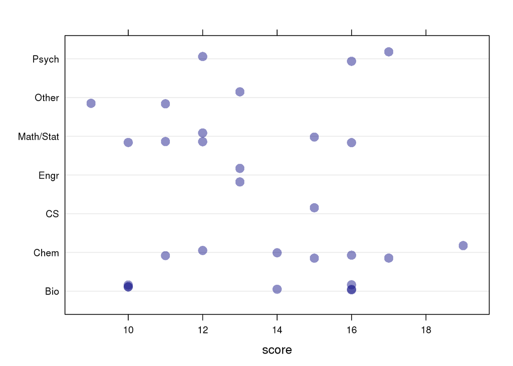

```
## Source: local data frame [7 x 5]
##
##        dept     n avg_score max_score min_score
##      (fctr) (int)     (dbl)     (int)     (int)
## 1     Other     3     11.00        13         9
## 2 Math/Stat     6     12.67        16        10
## 3      Engr     2     13.00        13        13
## 4       Bio     7     13.14        16        10
## 5      Chem     7     14.86        19        11
## 6        CS     1     15.00        15        15
## 7     Psych     3     15.00        17        12
```

## When should I submit my entry next year?

Is it better to submit as soon as the contest opens or to pour over the data for several days? Let’s see how the scores related to submission times.

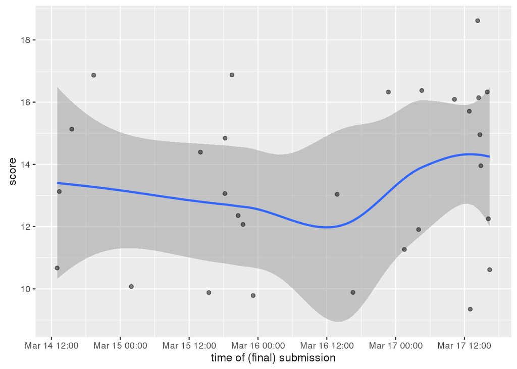